# Autocorrelation experiment: surface area

Debora

2023-09-22

H3: When the mean temperature is much greater than the optimal, strongly autocorrelated sequences starting hot will have a negative impact to the performance in comparison with both autocorrelated sequences starting colder and the no autocorrelation group. This is due to early mortality and/or reproduction suppression which occurs as a result of exposure to unfavorable conditions at the beginning of the experiment period.

### Get dataset

```
##    Experiment_Number Experiment_Start Experiment_End       Profile_name
## 47                81        27-Oct-22       1-Nov-22 simplelong37_095_1
## 52                82         3-Nov-22       8-Nov-22 simplelong37_000_2
## 72                85        24-Nov-22      29-Nov-22 simplelong37_000_5
##    Mean_temperature Treatment Incubator  Species Initial_area Final_area
## 47               37      0.95         3 Field_LM       0.1430     0.0700
## 52               37         0         2 Field_LM       0.1493     0.2277
## 72               37         0         2       LP       0.1680     0.1575
```

### Clean dataset

Exclude experiments outside thresholds established in methods (for standard deviation and autocorrelation of observed temperatures)

```r
datin <- datin[!(datin$Treatment == 0 & (datin$Obs_sd <= 2.1 | datin$Obs_sd >= 2.9))
               &!(datin$Treatment == 0.95 & (datin$Obs_sd <= 2.1 | datin$Obs_sd >= 2.9)),]

datin <- datin[!(datin$Treatment == 0 & (datin$Obs_ac <= -0.2 | datin$Obs_ac >= 0.2))
               &!(datin$Treatment == 0.95 & (datin$Obs_ac <= 0.92 | datin$Obs_ac >= 0.98)),]
```

### Exclude failed experiments

```r
datin <- subset(datin, !Errors == "y"|is.na(Errors))
```

### Remove constant temperature experiments

```r
datin <- subset(datin, !Treatment == "constant")
```

### Select high temperatures and Lemna minor only

```r
datin <- subset(datin, Mean_temperature == 37)
datin <- subset(datin, Species == "Field_LM")
```

### Select experiments containing complete surface area data

```r
datin <- datin[!is.na(datin$Initial_area),]
datin <- subset(datin, !(Initial_area > 0 & Final_area == 0))
datin$SA <- datin$Final_area - datin$Initial_area
```

### Check number of replicates available

```r
table(datin$Mean_temperature, datin$Treatment)
```

```
##
##      cold-hot hot-cold no autocorrelation
##   37        6        6                  8
```

### Calculate relative growth rate based on surface area change

```r
datin$r <- (log(datin$Final_area) - log(datin$Initial_area)) / 5
```

### Plot data

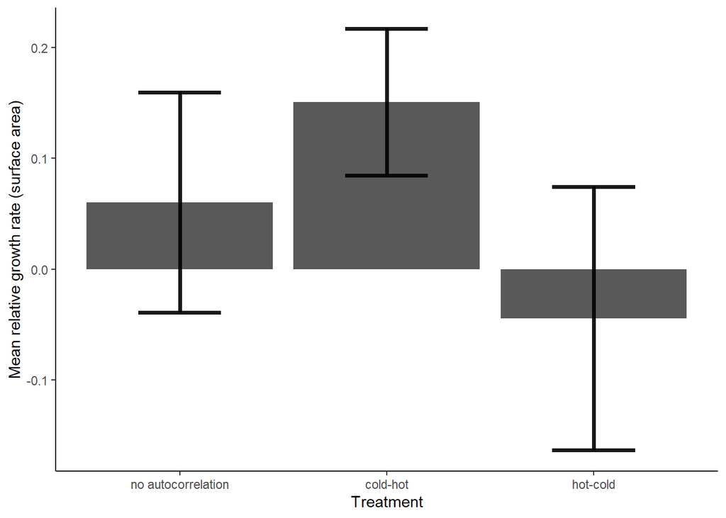

### Set variables to be used in the analyses as factors

```r
datin$Mean_temperature <- as.factor(datin$Mean_temperature)
datin$Experiment_Number <- as.factor(datin$Experiment_Number)
datin$Treatment <- as.factor(datin$Treatment)
datin$Incubator <- as.factor(datin$Incubator)
```

### Define reference levels for regressions

Control treatment: no autocorrelation

```r
datin <- within(datin, Treatment <- relevel(Treatment, ref = "no autocorrelation"))
```

### Fit a simple linear regression

```r
simple <- lm(r ~ Treatment,  data=datin)
summary(simple)
```

```
##
## Call:
## lm(formula = r ~ Treatment, data = datin)
##
## Residuals:
##      Min       1Q   Median       3Q      Max
## -0.15170 -0.06191  0.01651  0.05261  0.16585
##
## Coefficients:
##                   Estimate Std. Error t value Pr(>|t|)
## (Intercept)        0.06018    0.03445   1.747   0.0987 .
## Treatmentcold-hot  0.09049    0.05263   1.720   0.1037
## Treatmenthot-cold -0.10485    0.05263  -1.992   0.0626 .
## ---
## Signif. codes:  0 '***' 0.001 '**' 0.01 '*' 0.05 '.' 0.1 ' ' 1
##
## Residual standard error: 0.09745 on 17 degrees of freedom
## Multiple R-squared:  0.4154, Adjusted R-squared:  0.3467
## F-statistic: 6.041 on 2 and 17 DF,  p-value: 0.01042
```

### Barplot for model predictions

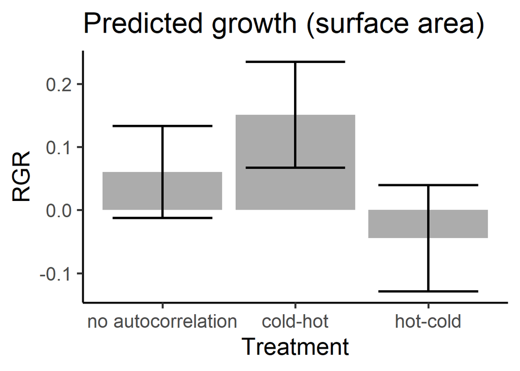

### Fitting candidate models with different combinations of random effects

```r
library(lme4)
exp_number <- lmer(r ~ Treatment + (1|Experiment_Number),  data=datin)
incubator <- lmer(r ~ Treatment + (1|Incubator),  data=datin)
exp_number_incub <- lmer(r ~ Treatment + (1|Incubator)+(1|Experiment_Number),  data=datin)
```

### Model assessment

```
## Random effect variances not available. Returned R2 does not account for random effects.
## Random effect variances not available. Returned R2 does not account for random effects.
```

| Name | Model | AIC | AIC_wt | AICc |
| --- | --- | --- | --- | --- |
| no random effects | lm | -31.63055 | 0.3029651 | NA |
| experiment number | lmerMod | -32.32200 | 0.4280934 | -28.03628 |
| incubator | lmerMod | -29.63055 | 0.1114546 | -25.34484 |
| incubator and experiment number | lmerMod | -30.32200 | 0.1574868 | -23.86046 |

Growth performance in supra optimal temperatures was evaluated using relative growth rate based on surface area comparisons in a linear mixed model.

The best model is the one including experiment number as a random effect. Most previous experiments (eg., night warming) have this same result.

The model, relative growth rate ~ treatment, included experiment number as random effect and was fitted using REML with the nloptwrap optimizer.

### Statistical analysis of best model

|  | r |  |  |
| --- | --- | --- | --- |
| Predictors | Estimates | CI | p |
| (Intercept) | 0.060 | -0.013 – 0.134 | 0.102 |
| Treatment [cold-hot] | 0.075 | -0.013 – 0.163 | 0.089 |
| Treatment [hot-cold] | -0.103 | -0.191 – -0.016 | **0.024** |
| Random Effects |  |  |  |
| σ<sup>2</sup> | 0.01 |  |  |
| τ<sub>00</sub> <sub>Experiment_Number</sub> | 0.00 |  |  |
| ICC | 0.42 |  |  |
| N <sub>Experiment_Number</sub> | 8 |  |  |
| Observations | 20 |  |  |
| Marginal R<sup>2</sup> / Conditional R<sup>2</sup> | 0.347 / 0.620 |  |  |

Marginal R2: considers the effects of fixed effects alone  
Conditional R2: considers the effects of both random and fixed effects

### Barplot for model predictions

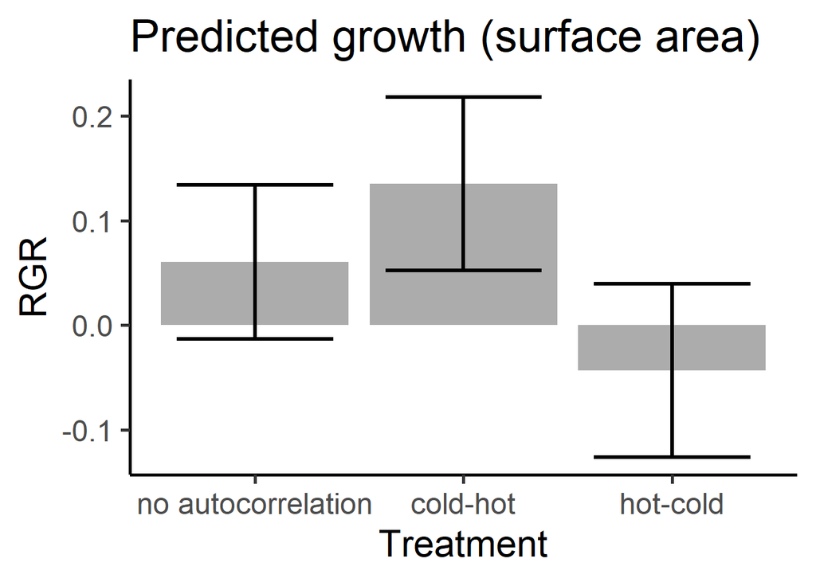

This analysis shows that, in comparison to the no autocorrelation group, the “hot-cold” treatment results in a reduction of growth in high temperatures, while no significant changes were observed in the “cold-hot” group.

### Post-hoc analyses

| 1 | estimate | SE | df | t.ratio | p.value |
| --- | --- | --- | --- | --- | --- |
| no autocorrelation - (cold-hot) | -0.0749 | 0.0412 | 10.9660 | -1.8173 | 0.2093 |
| no autocorrelation - (hot-cold) | 0.1034 | 0.0412 | 10.9660 | 2.5091 | 0.0693 |
| (cold-hot) - (hot-cold) | 0.1783 | 0.0441 | 10.8782 | 4.0436 | 0.0052 |

#### Check linear mixed model assumptions

```
##
##  Shapiro-Wilk normality test
##
## data:  resid(exp_number)
## W = 0.96583, p-value = 0.6654
```

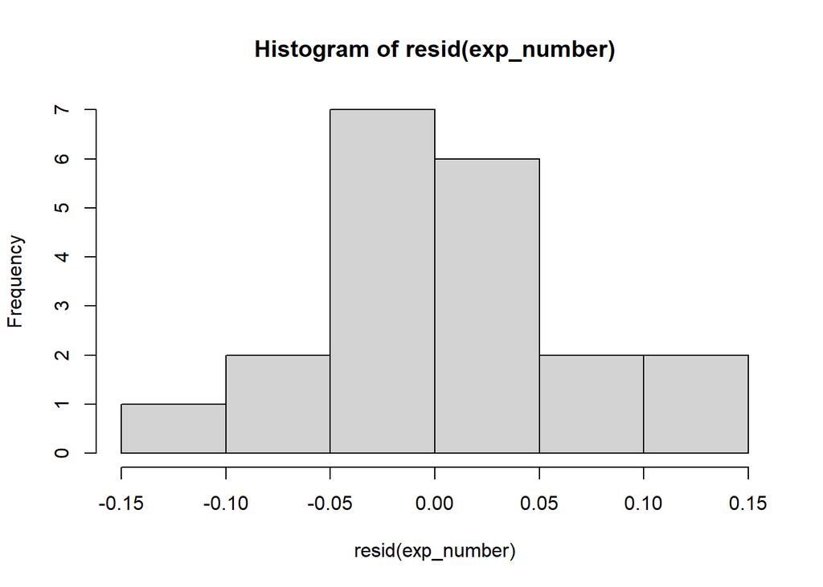

As the p-value is non-significant (p > 0.05), the null hypothesis is not rejected and we conclude that data has a normal distribution.

- Homogeneity of variance (homoscedasticity): plotting predicted vs residual values

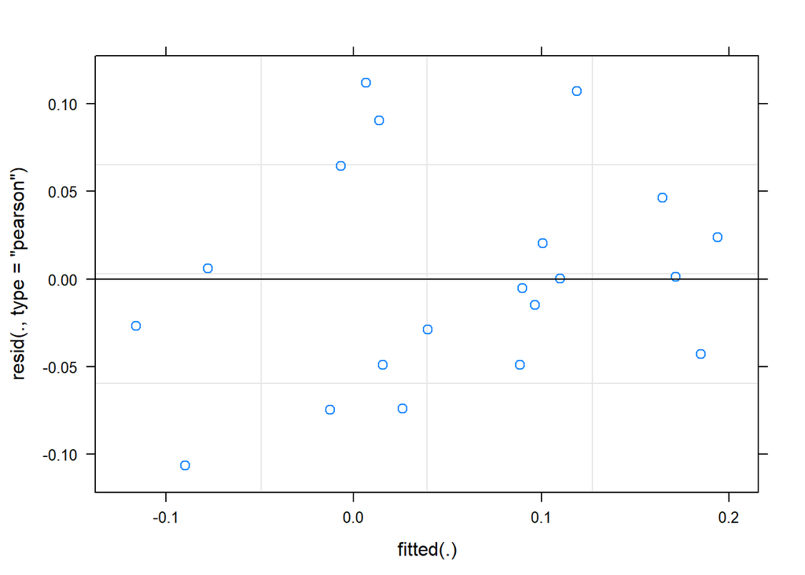

Dispersion looks homogeneous.

- Normal distribution

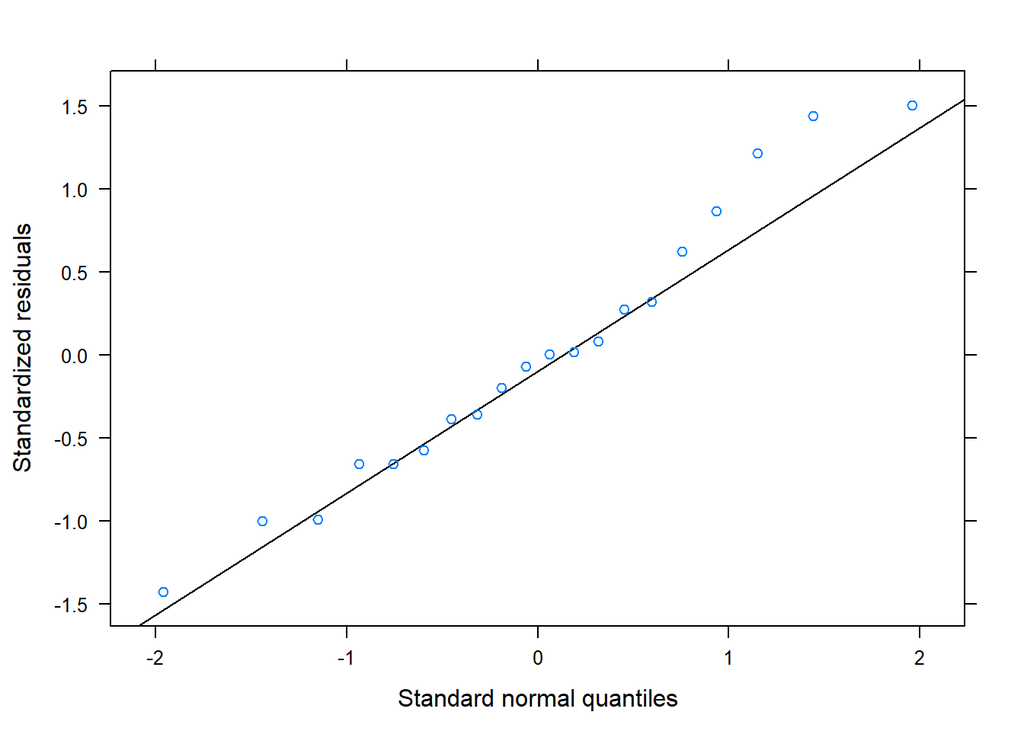

Most of the points fall within the normal line, suggesting that this assumption is not violated.

- Normal distribution of random effects

```
##
##  Shapiro-Wilk normality test
##
## data:  r_int
## W = 0.91243, p-value = 0.3715
```

Random effects are normally distributed.